신록예찬's 블로그

# (노트) 해들리위컴의 그래프레이어

Oct 13, 2021 • 신록예찬 • 10 min read

시각화

- import
- data
  - rpy2
  - *.csv 파일로 저장된것을 읽는 방법
  - github에 있는 *.csv를 읽어오는 방법
- data 설명
- 기본산점도 (2차원)
- 산점도응용 (3차원)
  - 산점도 + 점크기변경
- 산점도 + 투명도변경
  - 산점도 + 투명도, 크기 같이 변경 (3개의 변수, 4개의 심미성)
  - 산점도 + 형태
  - 산점도 + 색깔
  - 적합선추가
- 산점도응용2 (4차원)
- 결론

`-` ref: https://r4ds.had.co.nz/data-visualisation.html 의 Chapter 2

### import

```python
import pandas as pd
from plotnine import *
```

### data

#### rpy2

```python
import rpy2
%load_ext rpy2.ipython
```

```
The rpy2.ipython extension is already loaded. To reload it, use:
  %reload_ext rpy2.ipython
```

```python
%%R
## 여기는 R처럼 쓸 수 있다.
a<-c(1,2,3)
a+1
```

```
[1] 2 3 4
```

```python
a # R에서 정의된 변수는 파이썬에서는 쓸수없음. --> 일반적인 주피터셀과 %%R 로 시작하는 셀은 서로 독립적이다.
```

```
---------------------------------------------------------------------------
NameError                                 Traceback (most recent call last)
/tmp/ipykernel_16460/1917113226.py in <module>
----> 1 a # R에서 정의된 변수는 파이썬에서는 쓸수없음. --> 일반적인 주피터셀과 %%R 로 시작하는 셀은 서로 독립적이다.

NameError: name 'a' is not defined
```

`-` 주피터가 사실상 2개의 커널을 동시에 연결하고 있는 셈

```python
%%R
library(tidyverse)
mpg
```

```
# A tibble: 234 × 11
   manufacturer model      displ  year   cyl trans drv     cty   hwy fl    class
   <chr>        <chr>      <dbl> <int> <int> <chr> <chr> <int> <int> <chr> <chr>
 1 audi         a4           1.8  1999     4 auto… f        18    29 p     comp…
 2 audi         a4           1.8  1999     4 manu… f        21    29 p     comp…
 3 audi         a4           2    2008     4 manu… f        20    31 p     comp…
 4 audi         a4           2    2008     4 auto… f        21    30 p     comp…
 5 audi         a4           2.8  1999     6 auto… f        16    26 p     comp…
 6 audi         a4           2.8  1999     6 manu… f        18    26 p     comp…
 7 audi         a4           3.1  2008     6 auto… f        18    27 p     comp…
 8 audi         a4 quattro   1.8  1999     4 manu… 4        18    26 p     comp…
 9 audi         a4 quattro   1.8  1999     4 auto… 4        16    25 p     comp…
10 audi         a4 quattro   2    2008     4 manu… 4        20    28 p     comp…
# … with 224 more rows
```

```python
mpg # 당연히 이 변수는 파이썬에 없다.
```

[output not shown]

```python
%R -o mpg # R에 있는 변수를 파이썬으로 옮긴다
```

```python
mpg
```

|  | manufacturer | model | displ | year | cyl | trans | drv | cty | hwy | fl | class |
| --- | --- | --- | --- | --- | --- | --- | --- | --- | --- | --- | --- |
| 1 | audi | a4 | 1.8 | 1999 | 4 | auto(l5) | f | 18 | 29 | p | compact |
| 2 | audi | a4 | 1.8 | 1999 | 4 | manual(m5) | f | 21 | 29 | p | compact |
| 3 | audi | a4 | 2.0 | 2008 | 4 | manual(m6) | f | 20 | 31 | p | compact |
| 4 | audi | a4 | 2.0 | 2008 | 4 | auto(av) | f | 21 | 30 | p | compact |
| 5 | audi | a4 | 2.8 | 1999 | 6 | auto(l5) | f | 16 | 26 | p | compact |
| ... | ... | ... | ... | ... | ... | ... | ... | ... | ... | ... | ... |
| 230 | volkswagen | passat | 2.0 | 2008 | 4 | auto(s6) | f | 19 | 28 | p | midsize |
| 231 | volkswagen | passat | 2.0 | 2008 | 4 | manual(m6) | f | 21 | 29 | p | midsize |
| 232 | volkswagen | passat | 2.8 | 1999 | 6 | auto(l5) | f | 16 | 26 | p | midsize |
| 233 | volkswagen | passat | 2.8 | 1999 | 6 | manual(m5) | f | 18 | 26 | p | midsize |
| 234 | volkswagen | passat | 3.6 | 2008 | 6 | auto(s6) | f | 17 | 26 | p | midsize |

234 rows × 11 columns

#### *.csv 파일로 저장된것을 읽는 방법

```python
mpg.to_csv("2021-10-13-mpg.csv") # 이렇게하면 저장이 되고
```

```python
pd.read_csv("2021-10-13-mpg.csv") # 이렇게하면 읽어진다.
```

|  | Unnamed: 0 | manufacturer | model | displ | year | cyl | trans | drv | cty | hwy | fl | class |
| --- | --- | --- | --- | --- | --- | --- | --- | --- | --- | --- | --- | --- |
| 0 | 1 | audi | a4 | 1.8 | 1999 | 4 | auto(l5) | f | 18 | 29 | p | compact |
| 1 | 2 | audi | a4 | 1.8 | 1999 | 4 | manual(m5) | f | 21 | 29 | p | compact |
| 2 | 3 | audi | a4 | 2.0 | 2008 | 4 | manual(m6) | f | 20 | 31 | p | compact |
| 3 | 4 | audi | a4 | 2.0 | 2008 | 4 | auto(av) | f | 21 | 30 | p | compact |
| 4 | 5 | audi | a4 | 2.8 | 1999 | 6 | auto(l5) | f | 16 | 26 | p | compact |
| ... | ... | ... | ... | ... | ... | ... | ... | ... | ... | ... | ... | ... |
| 229 | 230 | volkswagen | passat | 2.0 | 2008 | 4 | auto(s6) | f | 19 | 28 | p | midsize |
| 230 | 231 | volkswagen | passat | 2.0 | 2008 | 4 | manual(m6) | f | 21 | 29 | p | midsize |
| 231 | 232 | volkswagen | passat | 2.8 | 1999 | 6 | auto(l5) | f | 16 | 26 | p | midsize |
| 232 | 233 | volkswagen | passat | 2.8 | 1999 | 6 | manual(m5) | f | 18 | 26 | p | midsize |
| 233 | 234 | volkswagen | passat | 3.6 | 2008 | 6 | auto(s6) | f | 17 | 26 | p | midsize |

234 rows × 12 columns

`-` 무언가 잘못되었다?

`-` 저장된 파일을 확인해보면 앞에 불필요한 인덱스가 저장되어있음.

`-` 다시저장하자..

```python
mpg.to_csv("2021-10-13-mpg.csv",index=False)
```

```python
pd.read_csv("2021-10-13-mpg.csv") # 이렇게하면 읽어진다.
```

|  | manufacturer | model | displ | year | cyl | trans | drv | cty | hwy | fl | class |
| --- | --- | --- | --- | --- | --- | --- | --- | --- | --- | --- | --- |
| 0 | audi | a4 | 1.8 | 1999 | 4 | auto(l5) | f | 18 | 29 | p | compact |
| 1 | audi | a4 | 1.8 | 1999 | 4 | manual(m5) | f | 21 | 29 | p | compact |
| 2 | audi | a4 | 2.0 | 2008 | 4 | manual(m6) | f | 20 | 31 | p | compact |
| 3 | audi | a4 | 2.0 | 2008 | 4 | auto(av) | f | 21 | 30 | p | compact |
| 4 | audi | a4 | 2.8 | 1999 | 6 | auto(l5) | f | 16 | 26 | p | compact |
| ... | ... | ... | ... | ... | ... | ... | ... | ... | ... | ... | ... |
| 229 | volkswagen | passat | 2.0 | 2008 | 4 | auto(s6) | f | 19 | 28 | p | midsize |
| 230 | volkswagen | passat | 2.0 | 2008 | 4 | manual(m6) | f | 21 | 29 | p | midsize |
| 231 | volkswagen | passat | 2.8 | 1999 | 6 | auto(l5) | f | 16 | 26 | p | midsize |
| 232 | volkswagen | passat | 2.8 | 1999 | 6 | manual(m5) | f | 18 | 26 | p | midsize |
| 233 | volkswagen | passat | 3.6 | 2008 | 6 | auto(s6) | f | 17 | 26 | p | midsize |

234 rows × 11 columns

`-` 제대로 되었음

#### github에 있는 *.csv를 읽어오는 방법

```python
pd.read_csv("https://raw.githubusercontent.com/miruetoto/yechan/master/_notebooks/2021-10-13-mpg.csv")
```

|  | manufacturer | model | displ | year | cyl | trans | drv | cty | hwy | fl | class |
| --- | --- | --- | --- | --- | --- | --- | --- | --- | --- | --- | --- |
| 0 | audi | a4 | 1.8 | 1999 | 4 | auto(l5) | f | 18 | 29 | p | compact |
| 1 | audi | a4 | 1.8 | 1999 | 4 | manual(m5) | f | 21 | 29 | p | compact |
| 2 | audi | a4 | 2.0 | 2008 | 4 | manual(m6) | f | 20 | 31 | p | compact |
| 3 | audi | a4 | 2.0 | 2008 | 4 | auto(av) | f | 21 | 30 | p | compact |
| 4 | audi | a4 | 2.8 | 1999 | 6 | auto(l5) | f | 16 | 26 | p | compact |
| ... | ... | ... | ... | ... | ... | ... | ... | ... | ... | ... | ... |
| 229 | volkswagen | passat | 2.0 | 2008 | 4 | auto(s6) | f | 19 | 28 | p | midsize |
| 230 | volkswagen | passat | 2.0 | 2008 | 4 | manual(m6) | f | 21 | 29 | p | midsize |
| 231 | volkswagen | passat | 2.8 | 1999 | 6 | auto(l5) | f | 16 | 26 | p | midsize |
| 232 | volkswagen | passat | 2.8 | 1999 | 6 | manual(m5) | f | 18 | 26 | p | midsize |
| 233 | volkswagen | passat | 3.6 | 2008 | 6 | auto(s6) | f | 17 | 26 | p | midsize |

234 rows × 11 columns

`-` 깃허브 저장소에 아예 데이터만 따로 모아서 관리하는것도 좋은 방법이에요.

### data 설명

`-` `displ`: 자동차의 엔진크기

`-` `hwy`: 연료효율, 동일한 연료로 얼마나 멀리 가냐?

`-` 자세한설명은 R에서 `?mpg` 로 알아볼것

### 기본산점도 (2차원)

`-` plotnine을 이용한 산점도

```python
ggplot(data=mpg)+geom_point(mapping=aes(x='displ',y='hwy'))
```

[output not shown]

- 산점도: 엔진크기와 연료효율은 반비례. (큰차일수록 연비가 안좋아요)

`-` ggplot2를 이용한 산점도

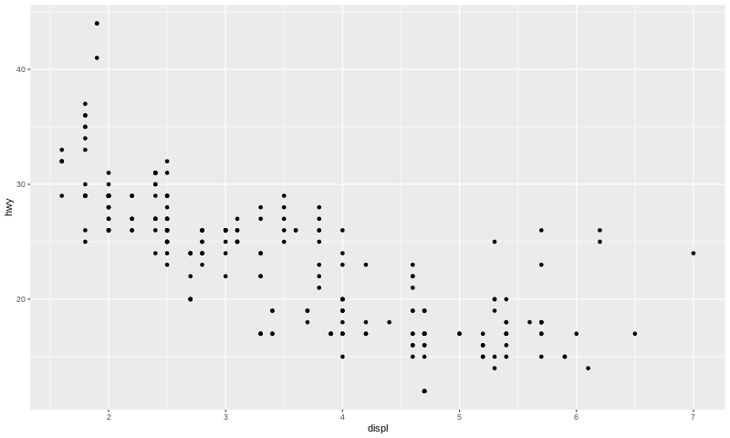

```python
%%R -w 800
ggplot(data=mpg)+geom_point(mapping=aes(x=displ,y=hwy)) ## 진짜 ggplot에서는 변수이름에 따옴표를 제외
```

`-` 객체지향적 느낌으로 산점도그리기

*step1: 도화지를 준비한다*

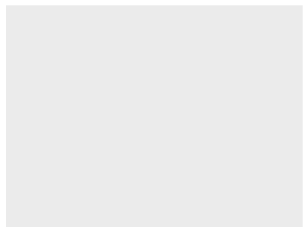

```python
fig=ggplot(data=mpg) # 도화지
fig
```

*step2:변수와 에스테틱 사이의 맵핑을 설정한다*

```python
a1=aes(x='displ',y='hwy')
```

*step3: 점들의 집합으로 지옴을 하나 만든다*

```python
point1=geom_point(a1) # 점들의 집합 (지옴1)
```

- geom_point(): 점들을 그려! 어떻게??
- a1에서 설정된 표를 보고!

*step4: 도화지와 지옴을 합친다*

```python
fig+point1 # 도화지에 점들의 집합을 겹친다.
```

[output not shown]

`-` 빠르게 그리기: `mapping=`와 `data=`는 생략가능함

```python
ggplot(mpg)+geom_point(aes(x='displ',y='hwy'))
```

[output not shown]

### 산점도응용 (3차원)

`-` 엔진크기, 연비 이외에 자동차크기(class)도 함께 살펴 보고 싶음.

`-` 즉 3차원 자료를 보고 싶다는 의미 $\to$ 미나드의 천재성을 떠올려보자.

#### 산점도 + 점크기변경

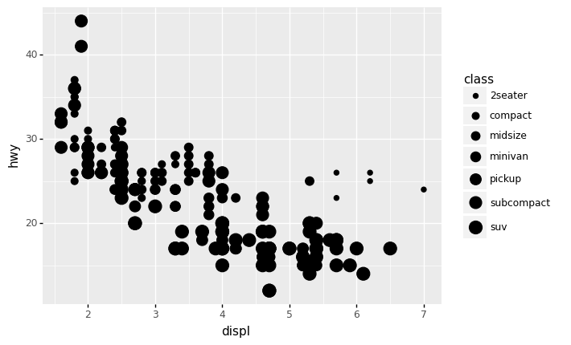

```python
ggplot(data=mpg)+geom_point(mapping=aes(x='displ',y='hwy',size= 'class'))
```

- 순서를 어떻게 아냐? $\to$ 모름. 그냥 알파벳 순서로 나열하다 보니까 저렇게 된것임

### 산점도 + 투명도변경

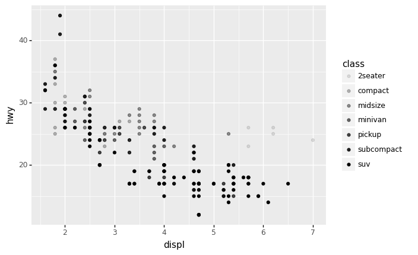

```python
ggplot(data=mpg)+geom_point(mapping=aes(x='displ',y='hwy',alpha= 'class'))
```

#### 산점도 + 투명도, 크기 같이 변경 (3개의 변수, 4개의 심미성)

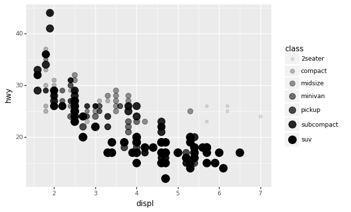

```python
ggplot(data=mpg)+geom_point(mapping=aes(x='displ',y='hwy',size= 'class', alpha='class'))
```

#### 산점도 + 형태

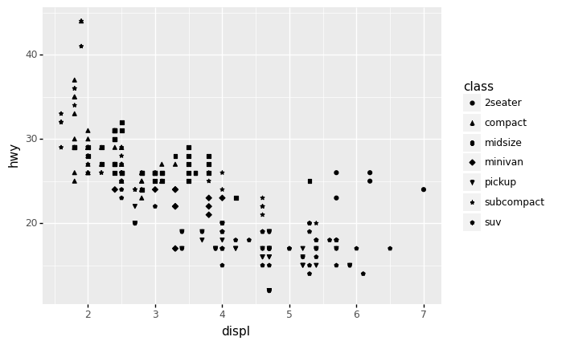

```python
ggplot(data=mpg)+geom_point(mapping=aes(x='displ',y='hwy',shape= 'class'))
```

#### 산점도 + 색깔

```python
ggplot(data=mpg)+geom_point(mapping=aes(x='displ',y='hwy',color= 'class'))
```

[output not shown]

`-` 객체지향적으로?

```python
a2=aes(x='displ',y='hwy',color= 'class')
```

```python
point2=geom_point(a2)
```

```python
fig+point2
```

[output not shown]

#### 적합선추가

`-` 객체지향적으로?

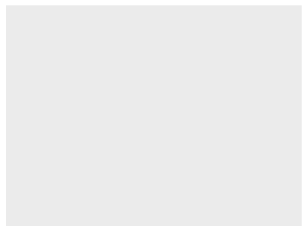

```python
fig
```

```python
a1,a2
```

```
({'x': 'displ', 'y': 'hwy'}, {'x': 'displ', 'y': 'hwy', 'color': 'class'})
```

```python
sline1=geom_smooth(a1)
```

```python
fig+point2
```

[output not shown]

```python
fig+point2+sline1
```

[output not shown]

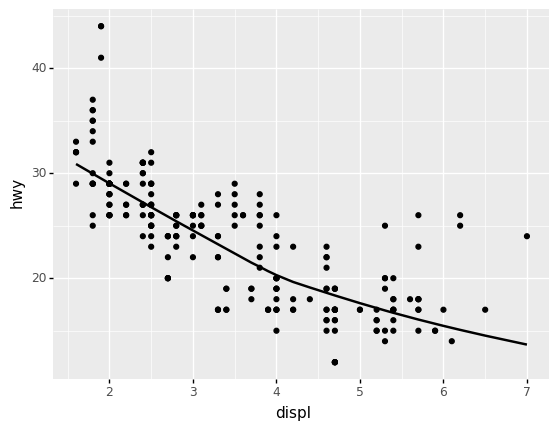

```python
fig+point1+sline1
```

`-` 명령어로 한번에 그리기

```python
ggplot(data=mpg)+geom_point(mapping=aes(x='displ',y='hwy',color='class'))+geom_smooth(mapping=aes(x='displ',y='hwy'))
```

[output not shown]

- 너무 그리기 어려움

`-` 공통적인 맵핑규칙은 ggplot()쪽으로 빼기도 한다. (figure 선언하는 곳에서 공통으로 선언함)

```python
ggplot(data=mpg,mapping=aes(x='displ',y='hwy'))+geom_point(mapping=aes(color='class'))+geom_smooth()
## 아래는 원래코드
# ggplot(data=mpg)+geom_point(mapping=aes(x='displ',y='hwy',color='class'))+geom_smooth(mapping=aes(x='displ',y='hwy'))
```

[output not shown]

`-` R에서는 confidence interval도 같이 나온다.

```
R[write to console]: `geom_smooth()` using method = 'loess' and formula 'y ~ x'
```

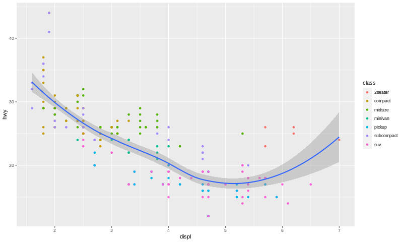

```python
%%R -w 800
ggplot(data=mpg,mapping=aes(x=displ,y=hwy))+geom_point(mapping=aes(color=class))+geom_smooth()
```

- 선도 파랗게 나옴

### 산점도응용2 (4차원)

```python
mpg.head()
```

|  | manufacturer | model | displ | year | cyl | trans | drv | cty | hwy | fl | class |
| --- | --- | --- | --- | --- | --- | --- | --- | --- | --- | --- | --- |
| 1 | audi | a4 | 1.8 | 1999 | 4 | auto(l5) | f | 18 | 29 | p | compact |
| 2 | audi | a4 | 1.8 | 1999 | 4 | manual(m5) | f | 21 | 29 | p | compact |
| 3 | audi | a4 | 2.0 | 2008 | 4 | manual(m6) | f | 20 | 31 | p | compact |
| 4 | audi | a4 | 2.0 | 2008 | 4 | auto(av) | f | 21 | 30 | p | compact |
| 5 | audi | a4 | 2.8 | 1999 | 6 | auto(l5) | f | 16 | 26 | p | compact |

`-` drv (전륜, 후륜, 4륜 구동) 에 따라서도 데이터를 시각화 하고 싶다.

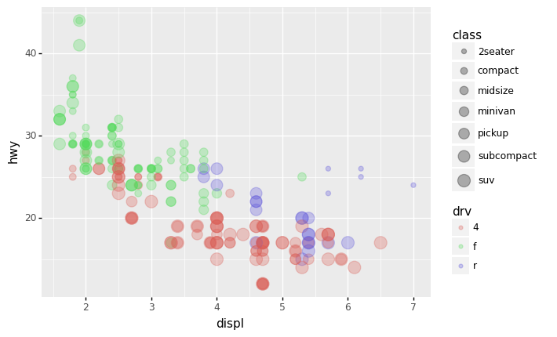

```python
ggplot(data=mpg,mapping=aes(x='displ',y='hwy'))+geom_point(mapping=aes(size='class',color='drv'),alpha=0.3)
```

`-` 객체지향적

```python
a1,a2
```

```
({'x': 'displ', 'y': 'hwy'}, {'x': 'displ', 'y': 'hwy', 'color': 'class'})
```

```python
a3=a2.copy()
a3
```

```
{'x': 'displ', 'y': 'hwy', 'color': 'class'}
```

```python
a3['color']='drv'
a3['size']='class'
```

```python
a3
```

```
{'x': 'displ', 'y': 'hwy', 'color': 'drv', 'size': 'class'}
```

```python
point3=geom_point(a3)
```

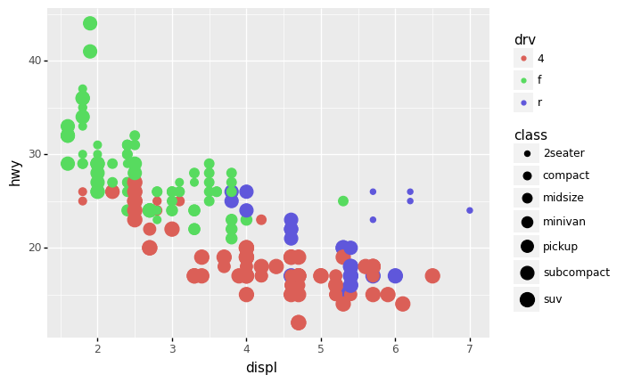

```python
fig+point3
```

- 앗, 투명도 조절!

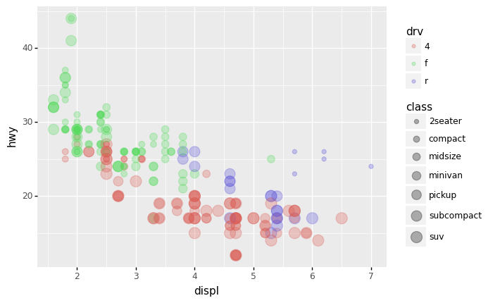

```python
point3=geom_point(a3,alpha=0.3)
fig+point3
```

`-` 여기에 선을 추가해봅시다.

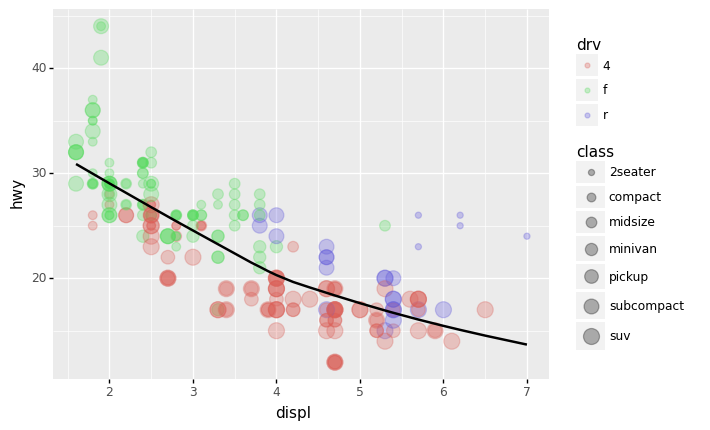

```python
fig+point3+sline1
```

`-` 각 그룹별로 선을 따로 그릴수도 있을까?

```python
a1,a2,a3
```

```
({'x': 'displ', 'y': 'hwy'},
 {'x': 'displ', 'y': 'hwy', 'color': 'class'},
 {'x': 'displ', 'y': 'hwy', 'color': 'drv', 'size': 'class'})
```

```python
a4=a2.copy()
```

```python
a4['color']='drv'
```

```python
a1,a2,a3,a4
```

```
({'x': 'displ', 'y': 'hwy'},
 {'x': 'displ', 'y': 'hwy', 'color': 'class'},
 {'x': 'displ', 'y': 'hwy', 'color': 'drv', 'size': 'class'},
 {'x': 'displ', 'y': 'hwy', 'color': 'drv'})
```

```python
sline2=geom_smooth(a4)
```

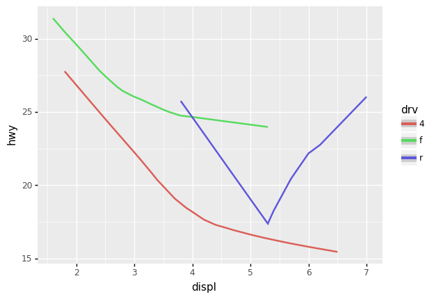

```python
fig+sline2
```

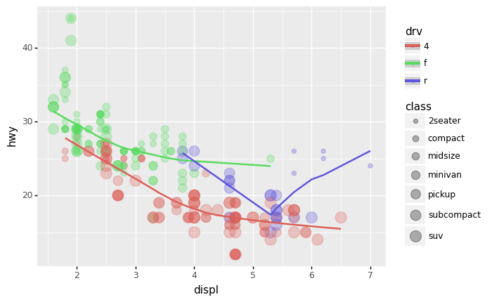

```python
fig+point3+sline2
```

`-` 선의 색깔은 동일하게 하고 선의 타입을 변경하여 그룹을 표시할수도 있지 않을까?

```python
sline3=geom_smooth(aes(x='displ',y='hwy',linetype='drv'),color='gray',size=0.5)
```

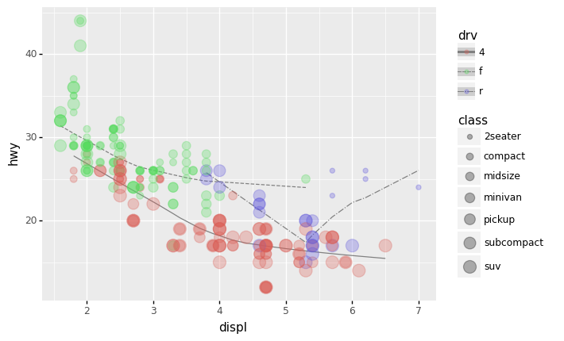

```python
fig+sline3+point3
```

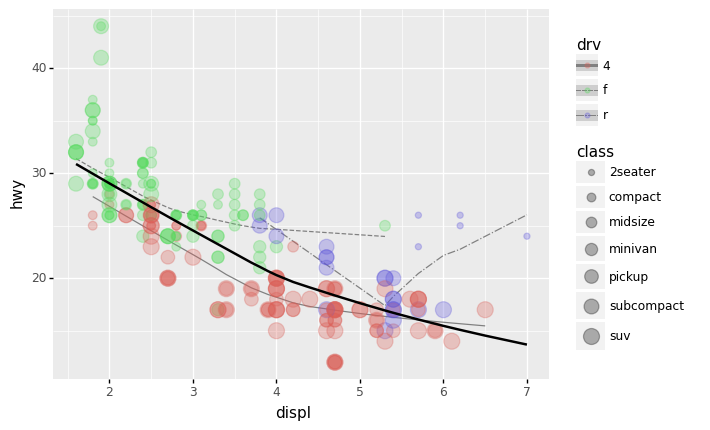

```python
fig+sline3+point3+sline1
```

- 붉은색점들만 적합된 곡선이 아래에 있음

`-` 고차원을 만드는 무기는 다양하다.

- 산점도(포인트지옴): 점의 크기, 점의 형태, 점의 색깔, 점의 투명도
- 라인플랏(스무스지옴, 라인지옴): 선의 형태, 선의 색깔, 선의 굵기

### 결론

`-` 잘 훈련한다면 여러가지 형태의 고차원 그래프를 우리도 그릴 수 있다. (마치 미나드처럼)

`-` 해들리위컴은 이러한 방법을 체계적으로 정리했다고 보여진다.

`-` 해들리위컴: 그래프는 데이터+지옴+맵핑(에스테틱)+스탯+포지션+축+패싯그리드 7개의 조합으로 이루어진다.

- 7개의 조합을 잘 마스터하면 어떠한 그래프도 그릴수 있다.
- 내생각: 지옴과 맵핑만 잘 이용해도 아주 다양하게 그릴수 있음